# Classification

# 1 Preparing the Data

The Wisconsin Breast Cancer dataset is available as a comma-delimited text file on the UCI Machine Learning Server (http://archive.ics.uci.edu/ml). The dataset contains 699 fine-needle aspirate samples, where 458 (65.5%) are benign and 241 (34.5%) are malignant. The dataset contains a total of 11 variables and doesn’t include the variable names in the file. Sixteen samples have missing data and are coded in the text file with a question mark (?).

The variables are as follows:

1. Sample code number id number
2. Clump Thickness 1 - 10
3. Uniformity of Cell Size 1 - 10
4. Uniformity of Cell Shape 1 - 10
5. Marginal Adhesion 1 - 10
6. Single Epithelial Cell Size 1 - 10
7. Bare Nuclei 1 - 10
8. Bland Chromatin 1 - 10
9. Normal Nucleoli 1 - 10
10. Mitoses 1 - 10
11. Class: (2 for benign, 4 for malignant)

```r
loc <- "https://archive.ics.uci.edu/ml/machine-learning-databases/"
ds <- "breast-cancer-wisconsin/breast-cancer-wisconsin.data"
url <- paste(loc, ds, sep = "")
breast <- read.table(url, sep = ",", header = F, na.strings = "?")
names(breast) <- c("ID", "clumpThickness", "sizeUniformity","shapeUniformity",
                   "maginalAdhesion","singleEpithelialCellSize","bareNuclei",
                   "blandChromatin","normalNucleoli","mitoses","class")
```

Split data into training and validation.

- The training sample will be used to create classification schemes using logistic regression or a decision tree.
- The validation sample will be used to evaluate the effectiveness of these schemes.

```r
df=breast[,-1]
df$class <- factor(df$class, levels = c(2,4),labels = c("benign","malignant"))
set.seed(1234)
train <- sample(nrow(df), 0.7*nrow(df))
df.train <- df[train,]
df.validate <- df[-train,]
table(df.train$class)
```

```
##
##    benign malignant
##       319       170
```

```r
table(df.validate$class)
```

```
##
##    benign malignant
##       139        71
```

# 2 Logistic Regression

We build the model using training data.

```r
fit.logit <- glm(class~., data = df.train, family = binomial())
summary(fit.logit)
```

```
##
## Call:
## glm(formula = class ~ ., family = binomial(), data = df.train)
##
## Deviance Residuals:
##      Min        1Q    Median        3Q       Max
## -2.24605  -0.08012  -0.03110   0.00266   2.11576
##
## Coefficients:
##                          Estimate Std. Error z value Pr(>|z|)
## (Intercept)              -12.4412     2.0547  -6.055  1.4e-09 ***
## clumpThickness             0.7407     0.2262   3.275  0.00106 **
## sizeUniformity            -0.0320     0.3399  -0.094  0.92500
## shapeUniformity            0.2073     0.3715   0.558  0.57680
## maginalAdhesion            0.5194     0.1708   3.041  0.00236 **
## singleEpithelialCellSize  -0.3217     0.2613  -1.231  0.21831
## bareNuclei                 0.5851     0.1881   3.111  0.00187 **
## blandChromatin             0.8599     0.2923   2.942  0.00326 **
## normalNucleoli             0.4036     0.1828   2.208  0.02725 *
## mitoses                    0.8923     0.3552   2.512  0.01200 *
## ---
## Signif. codes:  0 '***' 0.001 '**' 0.01 '*' 0.05 '.' 0.1 ' ' 1
##
## (Dispersion parameter for binomial family taken to be 1)
##
##     Null deviance: 621.04  on 477  degrees of freedom
## Residual deviance:  52.39  on 468  degrees of freedom
##   (11 observations deleted due to missingness)
## AIC: 72.39
##
## Number of Fisher Scoring iterations: 9
```

Predict using validation data.

```r
# Predict the probability
prob <- predict(fit.logit, df.validate, type = "response")
# Classification based on a cut-off value
logit.pred <- factor(prob > .5, levels = c(FALSE,TRUE), labels = c("benign","malignant"))
```

Check the performance.

```r
logit.perf <- table(df.validate$class, logit.pred, dnn = c("Actual","Predicted"))
logit.perf
```

```
##            Predicted
## Actual      benign malignant
##   benign       129         6
##   malignant      1        69
```

```r
library(pROC)
(roc.info <- roc(df.validate$class, prob))
```

```
##
## Call:
## roc.default(response = df.validate$class, predictor = prob)
##
## Data: prob in 135 controls (df.validate$class benign) < 70 cases (df.validate$class malignant).
## Area under the curve: 0.9899
```

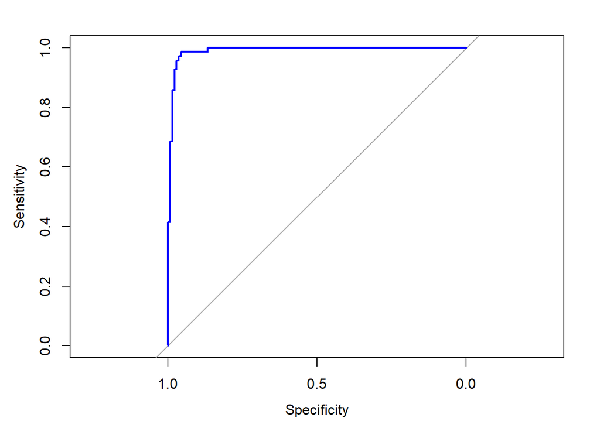

```r
plot(roc.info,col = "blue")
```

# 3 Decision Trees

**Grows the tree**: In order to choose a final tree size, examine the `cptable` component of the list returned by `rpart()`. It contains data about the prediction error for various tree sizes.

- `CP`: The complexity parameter is used to penalize larger trees. Smaller penalties tend to produce more complex models, which result in larger trees. Whereas larger penalties result in much smaller trees.
- `nsplit`: Tree size is defined by the number of branch splits. A tree with $n$ splits has $n+1$ terminal nodes.
- `rel error`: the error rate for a tree of a given size in the training sample.
- `xerror`: The cross-validated error is based on 10-fold cross validation using the training sample.
- `xstd`: The standard error of the cross-validation error.

```r
library(rpart)
set.seed(1234)
dtree <- rpart(class ~ ., data=df.train, method="class",
                 parms=list(split="information"))
dtree$cptable
```

```
##           CP nsplit  rel error    xerror       xstd
## 1 0.81764706      0 1.00000000 1.0000000 0.06194645
## 2 0.04117647      1 0.18235294 0.1823529 0.03169642
## 3 0.01764706      3 0.10000000 0.1588235 0.02970979
## 4 0.01000000      4 0.08235294 0.1235294 0.02637116
```

A good choice for the final tree size is **the smallest tree whose cross-validated error is within one standard error of the minimum cross-validated error value**. The minimum cross-validated error is 0.12 with a standard error of 0.03. In this case, the smallest with a cross-validated error between 0.09 and 0.15 is selected. A tree with four splits (cross-validated error = 0.1235294) fits the requirement, CP=0.01000000.

Gives a visual representation of the cross-validation results in an rpart object. The `plotcp()` function plots the cross-validated error against the complexity parameter.

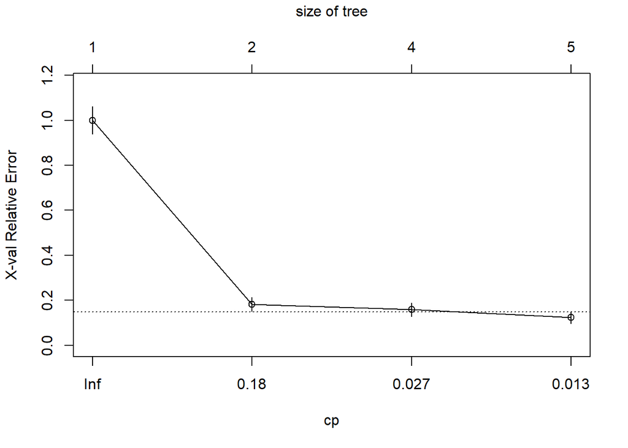

```r
plotcp(dtree)
```

**Prunes the tree**

Plot an rpart model using `prp()`:

- The `type=2` option draws the split labels below each node.
- The `extra=104` parameter include the probabilities for each class, along with the percentage of observations in each node.

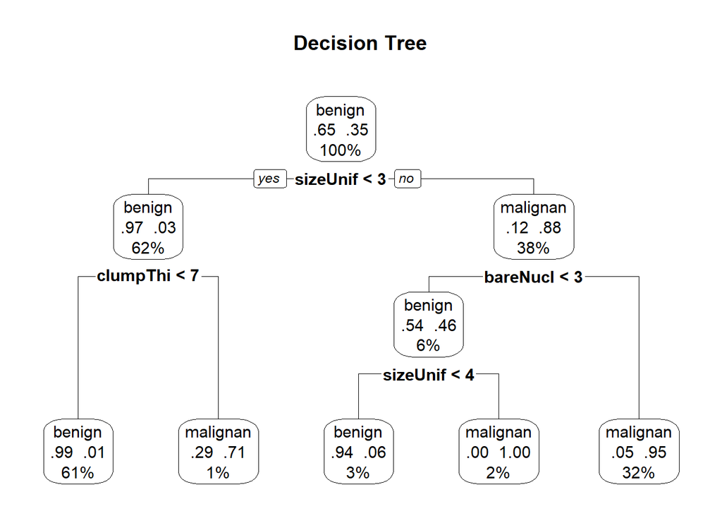

```r
dtree.pruned <- prune(dtree, cp=0.01)
# Plot an rpart model.
library(rpart.plot)
prp(dtree.pruned, type = 2, extra = 104,
      fallen.leaves = TRUE, main="Decision Tree")
```

**Classifies new cases**

```r
dtree.pred <- predict(dtree.pruned, df.validate, type="class")
dtree.perf <- table(df.validate$class, dtree.pred,
                      dnn=c("Actual", "Predicted"))
dtree.perf
```

```
##            Predicted
## Actual      benign malignant
##   benign       129        10
##   malignant      2        69
```